# EXERCISES

NU Pathology LearnR! Fall 2020 Session 2

## DATA VISUALIZATION

### EXTEND: Using built-in data and quick plots

You wouldn’t fully experience learning plotting with `ggplot2` if you didn’t work with the diamonds data set that is built in to `ggplot2`. This data set contains the prices and other attributes of almost 54,000 diamonds. Since the data set is available once you load the `ggplot2` package, you can use `diamonds` as you would any data object and R knows what you mean, as shown in the examples below. You can refer to the data set as `diamonds` or can assign it to a new variable if you like.

```r
summary(diamonds)
dia <- diamonds
```

We worked with the `ggplot()` in our session. There is another plotting function in `ggplot2` called `qplot()`. This was designed to allow for a ‘quick’ plot. We’ll experiment with the `qplot()` below to become familiar with it.

1. Create a `qplot()` that shows the relationship between price (price) and carat weight (carat) for the `diamonds` data set. (Use help to find out about the syntax and defaults for `qplot()`.)
2. Modify your code to ADD a smoothed line with error bars (created by geom “smooth”) to the scatterplot (geom “point”). (HINT: You want to ‘combine’ two geoms here)
3. Use `qplot()` to create a quick histogram of diamond price.

**Solution**

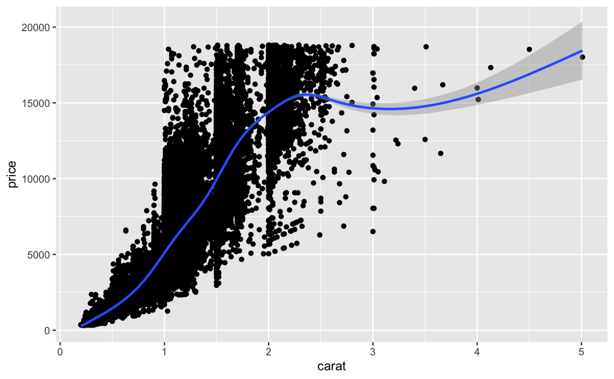

### PRACTICE: Creating spectacular plots

1. Use `ggplot()` to create a more sophisticated graph for the `diamonds` data that shows the relationship between price (price) and carat weight (carat) with coloring by the clarity rating (clarity). Adjust the transparency to better see overlapped points.

**Solution**

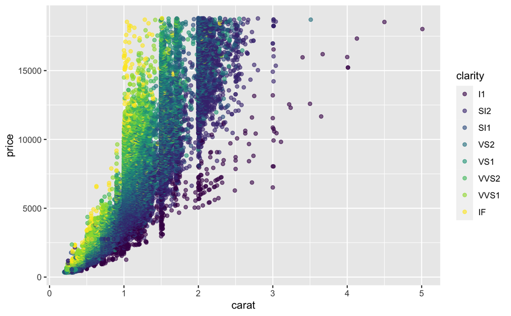

### PRACTICE: Faceting plots

As we learned, `ggplot2` has several faceting functions to divide plots into subplots based on categorical variable values.

1. Modify the plot above: instead of coloring points by the clarity rating, create individual plots for each group using faceting. Experiment with faceting into rows, columns, or a rectangular layout to see the difference and determine which may be best for this visualization.
2. Select your favorite version of the faceted plot and modify the scales to be “free”. What effect does this have on your plot?

**Solution**

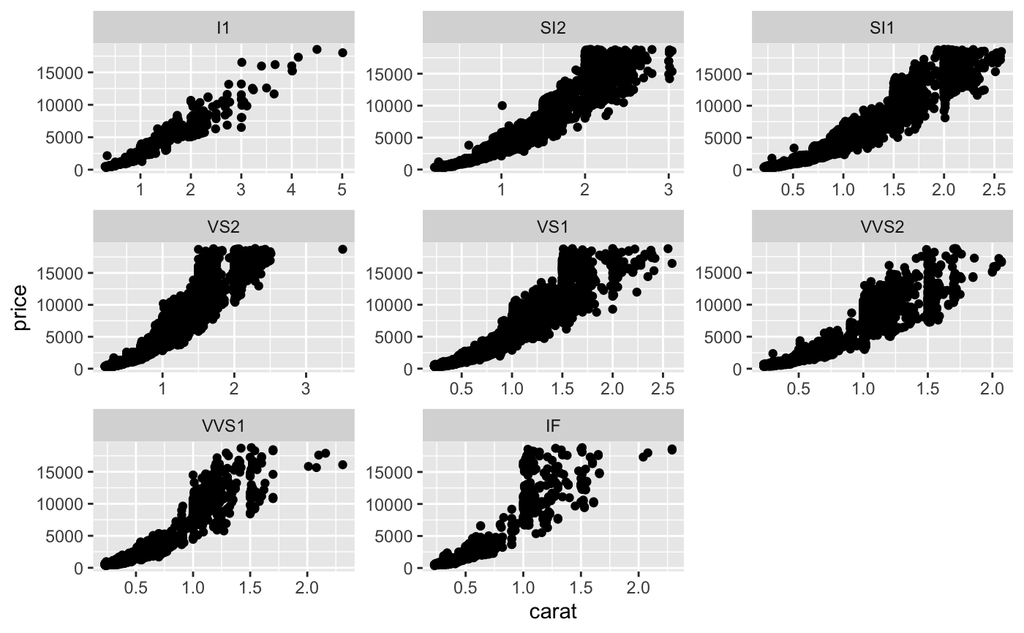